# 因果推断简介之六：工具变量（instrumental variable）

丁鹏

2013-08-28T12:42:57+00:00

`$$ \def\ind{{\perp\!\!\!\perp}} \def\nind{{\not\!\perp\!\!\!\perp}} $$`

为了介绍工具变量，我们首先要从线性模型出发。毫无疑问，线性模型是理论和应用统计（包括计量经济学和流行病学等）最重要的工具；对线性模型的深刻理解，可以说就是对一大半统计理论的理解。下面的第一部分先对线性模型，尤其是线性模型背后的假设做一个回顾。

# 一、线性回归和最小二乘法

线性模型和最小二乘的理论起源于高斯的天文学研究，“回归”（regression）这个名字则是 Francis Galton 在研究优生学的时候提出来的。为了描述的方便，我们假定回归的自变量只有一维，比如个体`$i$`是否接受某种处理（吸烟与否；参加某个工作；等等），记为`$D_i$`。 回归的因变量也是一维，表示我们关心的结果（是否有肺癌；是否找到工作培训与否；等等），记为`$Y_i$`。假定我们的研究中有 `$n$` 个个体，下面的线性模型用于描述`$D$`和`$Y$`之间的“关系”：

`$$Y_i = \alpha + \beta D_i + \varepsilon_i, i=1, \cdots, n. \quad \quad (1)$$`

一般情形下，我们假定个体间是独立的。模型虽简单，我们还是有必要做一些解释。首先，我们这里的讨论都假定`$D_i$`是随机变量，对应统计学中的随机设计 （random design）的情形；这和传统统计学中偏好的固定设计（fixed design）有点不同—那里假定`$D_i$`总是固定的。（统计学源于实验设计，那里的解释变量都是可以控制的，因此统计学教科书有假定固定设计的传统。）假定`$D_i$`是随机的，既符合很多社会科学和流行病学的背景，又会简化后面的讨论。另外一个问题是 `$\varepsilon_i$`，它到底是什么含义？Rubin 曾经嘲笑计量经济学家的`$\varepsilon_i$`道：为了使得线性模型的等式成立，计量经济学家必须加的一项，就叫`$\varepsilon_i$`。批评的存在并不影响这个线性模型的应用；关键的问题在于，我们在这个`$\varepsilon_i$`上加了什么假定呢？最根本的假定是：

`$$ E(\varepsilon_i) = 0, \text{ and } \text{cov}(D_i, \varepsilon_i) = 0. \quad \quad (2) $$`

不同的教科书稍有不同，比如 Wooldridge 的书上假定`$E(\varepsilon_i\mid D_i ) =0$`，很显然，这蕴含着上面两个假定。零均值的假定并不强，因为 `$\alpha$` “吸收”了`$\varepsilon_i$`的均值；关键在第二个协方差为零的假定—它通常被称为“外生性”（exogeneity）假定。在这个假定下，我们在 (1) 的两边关于`$D_i$`取协方差，便可以得到：

`$$\text{cov}(Y_i, D_i )= \beta \text{var}(D_i),$$`

因此，`$\beta = \text{cov}(Y_i, D_i) / \text{var}(D_i)$`，我们立刻得到了矩估计：

`$$\widehat{\beta}_{OLS} = \frac{ \sum_{i=1}^n (Y_i – \bar{Y}) (D_i – \bar{D}) } { \sum_{i=1}^n (D_i – \bar{D})^2 }.$$`

上面的估计式也是通常的最小二乘解，这里只是换了一个推导方式。如果将 (1) 看成一个数据生成的机制，在假定 (2) 下我们的确可以估计出因果作用`$\beta$`.

# 二、内生性和工具变量

问题的关键是假定 (2) 很多时候并不成立（`$\text{cov}(D_i, \varepsilon_i)\neq 0$`），比如，吸烟的人群和不吸烟的人群本身很不相同，参加工作培训的人可能比不参加工作培训的人有更强的找工作动机，等等。因此，包含个体`$i$`其他所有隐藏信息的变量`$\varepsilon_i$`不再与`$D_i$`不相关了—这被称为“内生性”（endogeneity）。这个时候，最小二乘估计收敛到`$\beta + \text{cov}(D,\varepsilon)/\text{var}(D)$`, 因而在`$\text{cov}(D,\varepsilon)\neq 0$`时不再是`$\beta$`的相合估计。

前面几次因果推断的介绍中提到，完全的随机化实验，可以给我们有效的因果推断。但是很多问题中，强制性的随机化实验是不现实或者不符合伦理的。比如，我们不能强制某些人吸烟，或者不吸烟。但是，“鼓励性实验”依然可行。我们可以随机地给吸烟的人以某种金钱的奖励，如果他们放弃吸烟，则获得某种经济上的优惠。将这个“鼓励性”的变量记为`$Z_i$`，它定义为是否被鼓励的示性变量，取值 0-1。由于我们的鼓励是完全随机的，有理由假定`$\text{cov}(Z_i, \varepsilon_i)=0$`。

以上的各个假定，可以用下面的一个图来形象的描述。

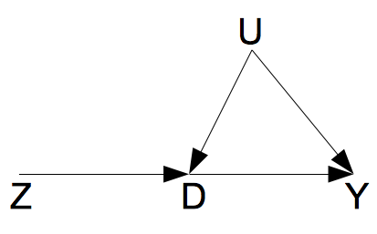

iv

如图所示，由于`$D$`和`$Y$`之间存在一个混杂因素`$U$`，两者之间的因果作用是不可以用线性回归相合估计的。工具变量`$Z$`的存在，使得`$D$`到`$Y$`的因果作用的识别成为了可能。这里的工具变量`$Z$`满足如下的条件: `$Z\ind U, Z\nind D$`，并且`$Z\ind Y|(D,U)$`。第三个条件，可以理解成为“无 `$Z$`到`$Y$`的直接作用”。

此时，我们在线性模型 (1) 两边关于`$Z_i$`取协方差，得到

`$$\text{cov}(Z_i, Y_i) = \beta \text{cov} (Z_i, D_i),$$`

因此，`$\beta = \frac{ \text{cov}(Z_i, Y_i)} {\text{cov} (Z_i, D_i) } $`，我们立刻得到如下的矩估计：

`$$\widehat{\beta}_{IV} = \frac{ \sum_{i=1}^n (Y_i – \bar{Y}) (Z_i – \bar{Z})}{ \sum_{i=1}^n (D_i – \bar{D}) (Z_i – \bar{Z}) } .\quad \quad (3)$$`

根据大数定律，这个“工具变量估计”是`$\beta$`的相合估计量。上面的式子对一般的`$Z_i$`都是成立的；当`$Z_i$`是 0-1 变量时，上面的式子可化简成：

`$$\widehat{\beta}_{IV} = \frac{ \bar{Y}_1 – \bar{Y}_0 } { \bar{D}_1 – \bar{D}_0 },$$`

其中`$\bar{Y}_1$`表示`$Z_i=1$`组的平均结果，`$\bar{Y}_0$`表示`$Z_i=0$`组的平均结果，关于`$D$`的定义类似。上面的估计量，很多时候被称为 Wald 估计量（它的直观含义是什么呢？） 需要注意的是，(3) 要求`$\text{cov}(Z_i,D_i)\neq 0$`，即“鼓励”对于改变人的吸烟行为是有效的；否则上面的工具变量估计量在大样本下趋于无穷大。

# 三、潜在结果视角下的因果作用

工具变量估计量在文献中存在已有很多年了，一直到了 Angrist, Imbens and Rubin (1996) 年的文章出现，才将它和潜在结果视角下的因果推断联系起来。关于 Neyman 引进的潜在结果，需要回顾这一系列的第二篇文章。

（随机化）`$Z_i \ind \{ D_i(1), D_i(0), Y_i(1), Y_i(0) \}.$`

由于个体的结果`$Y$`直接受到所受的处理`$D$`的影响，而不会受到是否受鼓励`$Z$`的影响，下面的排除约束（exclusion restriction）的假定，很多时候也是合理的：

（排除约束）`$D_i(1) = D_i(0)$` 蕴含着 `$Y_i(1) = Y_i(0)$`.

上面的假定表明，当随机化的“鼓励”`$Z$`不会影响是否接受处理`$D$`时，随机化的“鼓励” `$Z$`也不会影响结果变量`$Y$`。也可以理解成，随机化的“鼓励” `$Z$` 仅仅通过影响是否接受处理`$D$`来影响结果`$Y$`，或者说，随机化“鼓励” `$Z$`本身对与结果变量`$Y$`没有“直接作用”。

以上三个假定下，我们得到： `$$ \begin{eqnarray*} &&ACE(Z \rightarrow Y) \\ & = & E\{Y_i(1)\} -E\{Y_i(0)\} \\ &=& P\{ D_i(1)=1, D_i(0)=0\} E\{Y_i(1)-Y_i(0)\mid D_i(1)=1, D_i(0)=0 \}\\ &&+ P\{ D_i(1)=0, D_i(0)=0\} E\{Y_i(1)-Y_i(0)\mid D_i(1)=0, D_i(0)=0 \}\\ &&+P\{ D_i(1)=1, D_i(0)=1\} E\{Y_i(1)-Y_i(0)\mid D_i(1)=1, D_i(0)=1 \}\\ &=& P\{ D_i(1)=1, D_i(0)=0\} E\{Y_i(1) -Y_i(0)\mid D_i(1)=1, D_i(0)=0 \}. \end{eqnarray*} $$`

单调使得 `$D$` 的潜在结果的组合只有三种；排除约束假定使得上面分解的后两个式子为`$0$`。由于对于 `$(D_i(1)=0, D_i(0)=0)$` 和 `$(D_i(1)=1, D_i(0)=1)$`两类人，随机化的“鼓励”对于`$D$`的作用为`$0$`，`$(D_i(1)=1, D_i(0)=0)$`一类人的比例就是`$Z$`对`$D$`平均因果作用：`$ACE(Z\rightarrow D) = P\{ D_i(1)=1, D_i(0)=0\} $`. 因此，

`$$ CACE= E\{Y_i(1)-Y_i(0)\mid D_i(1)=1, D_i(0)=0 \} = \frac{ ACE(Z \rightarrow Y) }{ ACE(Z\rightarrow D) }. $$`

上面的式子被定义为`$CACE$`是有理由的。它表示的是子总体`$(D_i(1)=1, D_i(0)=0)$`中，随机化对于结果的因果作用；由于这类人中随机化和接受的处理是相同的，它也表示处理对结果的因果作用。这类人接受处理与否完全由于是否接受鼓励而定，他们被成为“依从者”（complier），因为这类人群中的平均因果作用又被成为“依从者平均因果作用”（CACE：complier average causal effect）;计量经济学家称它为“局部处理作用”（LATE：local average treatment effect）。

由于`$Z$`是随机化的，它对于`$D$`和`$Y$`的平均因果作用都是显而易见可以得到的。因为`$\widehat{ACE}(Z\rightarrow D) = \bar{D}_1 – \bar{D}_0, \widehat{ACE}(Z\rightarrow Y) = \bar{Y}_1 – \bar{Y}_0$`，CACE 的一个矩估计便是

`$$ \frac{\widehat{ACE}(Z\rightarrow Y) } { \widehat{ACE}(Z\rightarrow D) } = \widehat{\beta}_{IV}.$$`

由此可见工具变量估计量的因果含义。上面的讨论既显示了工具变量对于识别因果作用的有效性，也揭示了它的局限性：我们只能识别某个子总体的平均因果作用；而通常情况下，我们并不知道某个个体具体属于哪个子总体。

# 四、实例

这部分给出具体的例子来说明上述理论的应用，具体计算用到了第五部分的一个函数（其中包括用delta方法算的抽样方差）。这里用到的数据来自一篇政治学的文章 Green et al. (2003) “Getting Out the Vote in Local Elections: Results from Six Door-to-Door Canvassing Experiments”，[数据点击此处可以在此下载](http://dvn.iq.harvard.edu/dvn/faces/study/StudyPage.xhtml?globalId=hdl:1902.1/21729&studyListingIndex=5_c49f1060ddaa41a23e5759168940)。

文章目的是研究某个社会实验是否能够提高投票率，实验是随机化的，但是并非所有的实验组的人都依从。因此这里的变量 `$Z$` 表示随机化的实验，`$D$` 表示依从与否，`$Y$` 是投票与否的示性变量。具体的数据描述，可参加前面提到的文章。

原始数据总结如下：

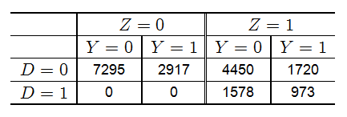

table

根据下一个部分的函数，我们得到如下的结果：

```r
CACE.IV(Y, D, Z)
$CACE
[1] 0.07914375

$se.CACE
           [,1]
[1,] 0.02273439

$p.value
             [,1]
[1,] 0.0004991073

$prob.complier
[1] 0.2925123

$se.complier
[1] 0.004871619
```

由此可见，这个实验对于提高投票率，有显著的作用。

# 五、R code

```r
## function for complier average causal effect
CACE.IV <- function(outcome, treatment, instrument) {
  Y <- outcome
  D <- treatment
  Z <- instrument
  N <- length(Y)

  Y1 <- Y[Z == 1]
  Y0 <- Y[Z == 0]
  D1 <- D[Z == 1]
  D0 <- D[Z == 0]

  mean.Y1 <- mean(Y1)
  mean.Y0 <- mean(Y0)
  mean.D1 <- mean(D1)
  mean.D0 <- mean(D0)

  prob.complier <- mean.D1 - mean.D0
  var.complier <- var(D1) / length(D1) + var(D0) / length(D0)
  se.complier <- var.complier^0.5

  CACE <- (mean.Y1 - mean.Y0) / (mean.D1 - mean.D0)

  ## COV
  pi1 <- mean(Z)
  pi0 <- 1 - pi1

  Omega <- c(
    var(Y1) / pi1, cov(Y1, D1) / pi1, 0, 0,
    cov(Y1, D1) / pi1, var(D1) / pi1, 0, 0,
    0, 0, var(Y0) / pi0, cov(Y0, D0) / pi0,
    0, 0, cov(Y0, D0) / pi0, var(D0) / pi0
  )
  Omega <- matrix(Omega, byrow = TRUE, nrow = 4)

  ## Gradient
  Grad <- c(1, -CACE, -1, CACE) / (mean.D1 - mean.D0)

  COV.CACE <- t(Grad) %*% Omega %*% Grad / N

  se.CACE <- COV.CACE^0.5

  p.value <- 2 * pnorm(abs(CACE / se.CACE), 0, 1, lower.tail = FALSE)

  ## results
  res <- list(
    CACE = CACE,
    se.CACE = se.CACE,
    p.value = p.value,
    prob.complier = prob.complier,
    se.complier = se.complier
  )

  return(res)
}
```